# Functions for Heterozygosity and $F_{st}$

Simina Boca and Guangchuan Ji

Innovation Center for Biomedical Informatics, Georgetown University  
Georgetown University

2018-10-26

# Contents

```r
knitr::opts_chunk$set(echo = TRUE, comment = NA, message = FALSE, warning = FALSE)
```

```r
library(knitr)
library(kableExtra)
```

# 1 Function to calculate the heterozygosity of a population at a locus

A diploid organism is heterozygous at a gene locus when its cells contain two different alleles of a gene. The cell or organism is called a heterozygote specifically for the allele in question, and therefore, heterozygosity refers to a specific genotype. High heterozygosity means lots of genetic variability. Low heterozygosity means little genetic variability.

We can use the expected heterozygosity to estimate the gene diversity. The expected heterozygosity in a population for a given locus with I distinct alleles is defined as $H = 1 - \sum_{i=1}^I p_{i}^2$, where $p_{i}$ is the frequency of allele i.

To calculate the expected heterozygosity, we can use the `get.het` function:

```r
get.het <- function(allele.freq)
{
1 - sum(allele.freq^2)
}
```

The input is the vector of allele ferquencies (should add up to 1).

## 1.1 Example

If we have three allele frequencies: 0.2, 0.3, 0.5, the expected heterozygosity is:

```r
get.het(c(0.2, 0.3, 0.5))
```

```
[1] 0.62
```

# 2 Function to calculate the heterozygosity of the admixed population

`get.Hadm.admix.general` function can calculate the heterozygosity of the admixed population.

```r
get.Hadm.admix.general <- function(pops, gamma)
{
  ##get admixed population
  admix.pop <- t(pops) %*% gamma
  ##calculate the heterozygosity of the admixed population
  Hadm <- get.het(admix.pop)
  Hadm
}
```

The input is a matrix with K rows and I columns (sums on rows is 1), vector of gammas (add up to 1).

## 2.1 Example

For the following data in a matrix, where each row represents a founder population and each column an allele for the locus of interest.

```r
pops <- matrix(nrow = 2, ncol = 10, c(0.059, 0.153, 0.132, 0.101, 0.08, 0.055, 0.106, 0.145, 0.048, 0.121, 1.000, 0.000, 0.000, 0.000, 0.000, 0.000, 0.000, 0.000, 0.000, 0.000), byrow=TRUE)
```

```r
rownames(pops) <- c("pop1", "pop2")
colnames(pops) <- paste("Allele",1:ncol(pops))
pops %>%
    kable() %>%
    kable_styling()
```

|  | Allele 1 | Allele 2 | Allele 3 | Allele 4 | Allele 5 | Allele 6 | Allele 7 | Allele 8 | Allele 9 | Allele 10 |
| --- | --- | --- | --- | --- | --- | --- | --- | --- | --- | --- |
| pop1 | 0.059 | 0.153 | 0.132 | 0.101 | 0.08 | 0.055 | 0.106 | 0.145 | 0.048 | 0.121 |
| pop2 | 1.000 | 0.000 | 0.000 | 0.000 | 0.00 | 0.000 | 0.000 | 0.000 | 0.000 | 0.000 |

With the given gamma:0.3, 0.7

```r
gamma <- c(0.3, 0.7)
```

Calculate the $H_{adm}$ of the admixed population:

```r
get.Hadm.admix.general(pops, gamma)
```

```
[1] 0.4750369
```

# 3 Function to calculate $F_{st}$ for pop.1 and pop.2

The “fixation index” $F_{st}$ is a measure of genetic divergence between an admixed population and its parental source populations. $F_{st}$ can be defined as $F_{st}$ = ($H_t$ - $H_s$)/H, where $H_t$ is the expected heterozygosity of the overall population, and $H_s$ is the mean expected heterozygosity across subpopulations.

To calculate $F_{st}$, use the `get.Fst` function:

```r
get.Fst <- function(pop.1, pop.2)
{
  meta.pop <- (pop.1 + pop.2)/2
  Ht <- get.het(meta.pop)
  Hs <- mean(c(get.het(pop.1), get.het(pop.2)))
  Fst <- (Ht - Hs)/Ht
  Fst
}
```

The input is pop.1, pop.2 (allele frequencies for the same locus for populations 1 and 2).

## 3.1 Example

The allele frequency of pop.1 is 0.3, and the allele frequency of pop.2 is 0.4, calculate the $F_{st}$:

```r
get.Fst(0.3, 0.4)
```

```
[1] 0.002849003
```

# 4 Function to calculate $F_{st}$ between a founder population and the admixed population for the K=2 founder population case

In the following sections, we try to calculate the $F_{st}$ between a founder population and the admixed population.

First, we consider a special case in which only 2 fouding populations give rise to an admixed population. And we use $\gamma_k$ to present the admixture fraction corresponding to population k.

For the K = 2 founder population case, we can use the `get.Fst.admix` function to calculate $F_{st}$ between pop.1 and the admixed population:

```r
get.Fst.admix <- function(pop.1, pop.2, gamma)
{
  pop.3 <- gamma*pop.1 + (1 - gamma)*pop.2
  meta.pop <- (pop.1 + pop.3)/2
  Ht <- get.het(meta.pop)
  Hs <- mean(c(get.het(pop.1), get.het(pop.3)))
  Fst <- (Ht - Hs)/Ht
  Fst
}
```

The input is pop.1, pop.2, gamma (gamma is the ancestry fraction corresponding to population 1).

## 4.1 Example

Consider the allele frequency of pop.1 is 0.3, the allele frequency of pop.2 is 0.4, and fraction $\gamma_k$ = 0.25.

Then calculate $F_{st}$ between pop.1 and the admixed population:

```r
get.Fst.admix(0.3, 0.4, 0.25)
```

```
[1] 0.001587022
```

# 5 Function to calculate $F_{st}$ for pop.1 and admixed population for the general case of K founding population

In this section, we consider the general case in which K founding populations give rise to an admixed population. Without loss of generality, we investigate $F_{st}$ between population 1 and the admixed population. And we use the `get.Fst.admix.general` function to get this $F_{st}$ value:

```r
get.Fst.admix.general <- function(pops, gamma)
{
  ##get admixed population
  admix.pop <- t(pops) %*% gamma

  ##get allele frequencies of "meta-population"
  meta.pop <- (pops[1, ] + admix.pop)/2

  Ht <- get.het(meta.pop)
  Hs <- mean(c(get.het(pops[1, ]), get.het(admix.pop)))
  Fst <- (Ht - Hs)/Ht
  Fst
}
```

The input is a matrix with K rows and I columns (sums on rows is 1), vector of gammas (add up to 1).

## 5.1 Example

For the following data in a matrix, where each row represents a founder population and each column an allele for the locus of interest.

```r
pops <- matrix(nrow = 2, ncol = 10, c(0.059, 0.153, 0.132, 0.101, 0.08, 0.055, 0.106, 0.145, 0.048, 0.121, 1.000, 0.000, 0.000, 0.000, 0.000, 0.000, 0.000, 0.000, 0.000, 0.000), byrow=TRUE)
```

```r
rownames(pops) <- c("pop1", "pop2")
colnames(pops) <- paste("Allele",1:ncol(pops))
pops %>%
    kable() %>%
    kable_styling()
```

|  | Allele 1 | Allele 2 | Allele 3 | Allele 4 | Allele 5 | Allele 6 | Allele 7 | Allele 8 | Allele 9 | Allele 10 |
| --- | --- | --- | --- | --- | --- | --- | --- | --- | --- | --- |
| pop1 | 0.059 | 0.153 | 0.132 | 0.101 | 0.08 | 0.055 | 0.106 | 0.145 | 0.048 | 0.121 |
| pop2 | 1.000 | 0.000 | 0.000 | 0.000 | 0.00 | 0.000 | 0.000 | 0.000 | 0.000 | 0.000 |

With the given gamma:0.3, 0.7

```r
gamma <- c(0.3, 0.7)
```

Calculate the $F_{st}$ between population 1 and the admixed population:

```r
get.Fst.admix.general(pops, gamma)
```

```
[1] 0.1518406
```

# 6 Function to create the plots related to $F_{st}$ and $H_{amd}$

We can use the `plot_HorF` function to create the plots related to $F_{st}$ and $H_{amd}$ of the data in the “allele.frequencie.no.extra” data file, and the x argument should be a list, y should be one of “Fst” or “Hadm”, users can set their own breaks and labels or use the default ones.

```r
plot_HorF <- function (x,# x should be a list including the allele frequencies of three populations(EUROPE, AMERICA, AFRICA)
                       y, # y should be either "Fst" or "Hadm"
                       breaks = default_break, # breaks are numeric vectors to categorize  Fst or Hamd.
                       label = default_label # the label of the legend.
){
  require(RColorBrewer)
  require(ggplot2)
  require(ggtern)

  if (!(y %in% c("Fst", "Hadm"))) stop("spacing must be either 'Fst' or 'Hadm'")
  alpha1 <- alpha2 <- seq(0,100,by=1)
  alpha3 = 100-alpha1-alpha2
  d <- expand.grid(alpha1, alpha2)

  row_sums <- rowSums(d)
  var3 <- 100-row_sums

  var3[var3<0] <- NA
  d$var3 <- var3
  d <- na.omit(d)

  gamma <- d/100

  sum_rows <- rowSums(gamma)


  colnames(gamma) <- paste("gamma", 1:3)

  allele.frequencies.no.extra$x <-  as.matrix(allele.frequencies.no.extra[[x]])[1:3,]
  position <- allele.frequencies.no.extra["x"]

  for(locus in names(position)){
    print(locus)

    ## get the allele frequencies

    p1 <- position[[locus]]["EUROPE",]
    p2 <- position[[locus]]["AMERICA",]
    p3 <- position[[locus]]["AFRICA",]

    print(p1)
    print(p2)
    print(p3)
  }

  ## get the admixed population
  gamma_1 <- gamma$`gamma 1`
  gamma_2 <- gamma$`gamma 2`
  gamma_3 <- gamma$`gamma 3`

  pop1 <- list() ## get p1*gamma1
  t <- 1
  for(a in gamma_1){
    admix.pop1 <- a*p1
    pop1[[t]] <- c(admix.pop1)
    t = t+1
  }


  pop2 <- list() ## get p2*gamma2
  t <- 1
  for(i in gamma_2){
    admix.pop2 <- i*p2
    pop2[[t]] <- c(admix.pop2)
    t = t+1
  }


  pop3 <- list() ## get p3*gamma3
  t <- 1
  for(n in gamma_3){
    admix.pop3 <- n*p3
    pop3[[t]] <- c(admix.pop3)
    t = t+1
  }


  pop1 <- t(as.data.frame(pop1))
  pop2 <- t(as.data.frame(pop2))
  pop3 <- t(as.data.frame(pop3))

  admix.pop <- pop1 + pop2 + pop3 ## get admix.pop
  row_sums <- data.frame(rowSums(admix.pop)) ## check if p1*gamma1 + p2*gamma2 + p3*gamma3 equals to 1


  ## get the hadm or Fst of the admixed population and create thire plots.
  if(y == "Hadm"){
    newlist <- list()
    t <- 1
    for(i in 1:nrow(admix.pop)){
      a <- admix.pop[i, ]
      H.1 <- get.het(a)
      newlist[[t]] <- c(H.1)
      t = t+1
    }

    hadm <- gamma$hadm <- newlist
    colnames(gamma)[1:3] <- c("gamma.1", "gamma.2", "gamma.3")

    gamma$hadm <- unlist(gamma$hadm)

    the_break <- quantile(as.numeric(hadm), probs = seq(0,1,0.125))
    the_break[9] <- 1
    the_break1 <- c(-1, the_break)
    default_break <- as.numeric(as.matrix(the_break1))


    the_break2 <- as.list(the_break1)
    the_break2[[10]] <- NULL
    the_break2[[1]] <- 0
    default_label <- as.numeric(the_break2)

    gamma$Hadm = cut(gamma$hadm, breaks)
    levels(gamma$Hadm) <- label

    ## create the plot


    mycol <- RColorBrewer::brewer.pal(9, 'YlOrRd')
    names(mycol) <- levels(gamma$Hadm)
    colScale <- scale_colour_manual(name = expression(H[adm]),values = mycol)
    Max <- gamma[which(gamma$hadm == max(gamma$hadm)), ]
    Max <- matrix(Max)
    g1 <- Max[1,1]
    g2 <- Max[2,1]
    g3 <- Max[3,1]
    g1 <- unlist(g1)
    g2 <- unlist(g2)
    g3 <- unlist(g3)

    pl <- ggtern::ggtern(gamma, aes(gamma.2, gamma.1, gamma.3, value=hadm)) + geom_point(aes(color=Hadm)) + colScale
    pl1 <- pl + theme_hideticks() + theme_hidelabels() + geom_mask() + annotate("point", x=g2, y=g1, z=g3, size=0.5) +
      annotate(geom = "text",
               x = c(0.5, 0.41, 0.0),
               y = c(0.0, 0.5, 0.59),
               z = c(0.5, 0.0, 0.5),
               angle = c(0, 0, 0),
               vjust = c(2.0, 0.5, 0.5),
               hjust = c(0.5, 1.3, -0.3),
               label = c("(0, 0.5, 0.5)", "(0.5, 0.5, 0)", "(0.5, 0 ,0.5)"),
               color = c("black", "black", "black"))
    pl2 <- pl1 + theme(legend.title = element_text(colour="black", size=10,  face="bold")) + guides(col = guide_legend(reverse = TRUE)) +
      annotate(geom = "text",
               x = c(0, 1, 0),
               y = c(1, 0, 0),
               z = c(0, 0, 1),
               label = c("(1, 0, 0)", "(0, 1, 0)", "(0, 0, 1)"),
               vjust = c(-1, 3, 3))
    temp1 <- expression("Native American"~gamma[2])
    temp2 <- expression("European"~gamma[1])
    temp3 <- expression("African"~gamma[3])
    temp4 <- "H[adm]"

    pl3 <- pl2 + theme_hidetitles() + annotate(geom = "text",
                                               x = c(1, 0, 0),
                                               y = c(0, 1, 0),
                                               z = c(0, 0, 1),
                                               label = c(as.character(temp1), as.character(temp2), as.character(temp3)),
                                               vjust = c(1, -2, 1),
                                               parse = TRUE)
    pl4 <- pl3 + annotate("text", x = 0, y = 0.75, z = 0.3, label = temp4, hjust = 4.0, vjust = -1.5, fontface = "bold", parse=TRUE) +
      annotate("segment", x=0.5, xend=0.15, y=0.5, yend=0.15, z=0, zend=0.05) + annotate("segment", x=0, xend=0.05, y=0.5, yend=0.15, z=0.5, zend=0.15) +
      annotate("segment", x=0.5, xend=0.15, y=0, yend=0.05, z=0.5, zend=0.15)


    pl4
  } else {
    newlist <- list()
    t <- 1
    for(i in 1:nrow(admix.pop)){
      a <- admix.pop[i, ]
      Fst.1 <- get.Fst(p1, a)
      newlist[[t]] <- c(Fst.1)
      t = t+1
    }

    F_st <- gamma$F_st <- newlist
    colnames(gamma)[1:3] <- c("gamma.1", "gamma.2", "gamma.3")

    gamma$F_st <- unlist(gamma$F_st)

    the_break <- quantile(as.numeric(F_st), probs = seq(0,1,0.125))
    the_break[9] <- 1
    the_break1 <- c(-1, the_break)
    default_break <- as.numeric(as.matrix(the_break1))


    the_break2 <- as.list(the_break1)
    the_break2[[10]] <- NULL
    the_break2[[1]] <- 0
    default_label <- as.numeric(the_break2)

    gamma$Fst = cut(gamma$F_st, breaks)
    levels(gamma$Fst) <- label

    ## create the plot

    mycol <- brewer.pal(9, 'YlOrRd')
    names(mycol) <- levels(gamma$Fst)
    colScale <- scale_colour_manual(name = expression(F[st]),values = mycol)
    Max <- gamma[which(gamma$F_st == max(gamma$F_st)), ]
    Max <- matrix(Max)
    g1 <- Max[1,1]
    g2 <- Max[2,1]
    g3 <- Max[3,1]
    g1 <- unlist(g1)
    g2 <- unlist(g2)
    g3 <- unlist(g3)

    p <- ggtern(gamma, aes(gamma.2, gamma.1, gamma.3, value=F_st)) + geom_point(aes(color=Fst)) + colScale
    p1 <- p + theme_hideticks() + theme_hidelabels() + geom_mask() + annotate("point", x = g2, y = g1, z = g3, size = 0.5) +
      annotate(geom = "text",
               x = c(0.5, 0.41, 0.0),
               y = c(0.0, 0.5, 0.59),
               z = c(0.5, 0.0, 0.5),
               angle = c(0, 0, 0),
               vjust = c(2.0, 0.5, 0.5),
               hjust = c(0.5, 1.3, -0.3),
               label = c("(0, 0.5, 0.5)", "(0.5, 0.5, 0)", "(0.5, 0 ,0.5)"),
               color = c("black", "black", "black"))
    p2 <- p1 + theme(legend.title = element_text(colour="black", size=10,  face="bold")) + guides(col = guide_legend(reverse = TRUE)) +
      annotate(geom = "text",
               x = c(0, 1, 0),
               y = c(1, 0, 0),
               z = c(0, 0, 1),
               label = c("(1, 0, 0)", "(0, 1, 0)", "(0, 0, 1)"),
               vjust = c(-1, 3, 3))
    temp1 <- expression("Native American"~gamma[2])
    temp2 <- expression("European"~gamma[1])
    temp3 <- expression("African"~gamma[3])
    p3 <- p2 + theme_hidetitles() + annotate(geom = "text",
                                             x = c(1, 0, 0),
                                             y = c(0, 1, 0),
                                             z = c(0, 0, 1),
                                             label = c(as.character(temp1), as.character(temp2), as.character(temp3)),
                                             vjust = c(1, -2, 1),
                                             parse = TRUE)

    p3
  }
}
```

## 6.1 Example

For example we can use this function to create the plot about $F_{st}$ at the [GATA101G01] locus and the plot about $H_{adm}$ at the [D2S1399] locus.

```
[1] "x"
        137         141         153         149         145         161
0.092465753 0.386986301 0.143835616 0.085616438 0.130136986 0.027397260
        157         165         169         177         173         133
0.109589041 0.017123288 0.003424658 0.003424658 0.000000000 0.000000000
        181         125
0.000000000 0.000000000
        137         141         153         149         145         161
0.316742081 0.062217195 0.170814480 0.088235294 0.009049774 0.039592760
        157         165         169         177         173         133
0.018099548 0.119909502 0.079185520 0.011312217 0.080316742 0.002262443
        181         125
0.001131222 0.001131222
        137         141         153         149         145         161
0.027272727 0.145454545 0.181818182 0.213636364 0.095454545 0.118181818
        157         165         169         177         173         133
0.127272727 0.022727273 0.036363636 0.000000000 0.022727273 0.009090909
        181         125
0.000000000 0.000000000
```

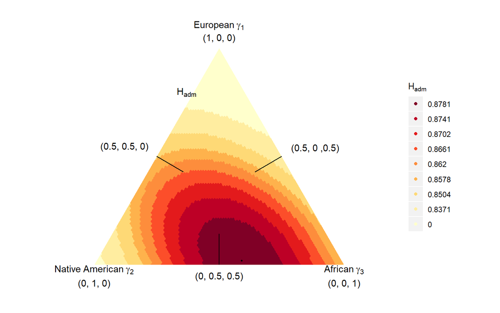

```r
load("D:/sdxjw/Documents/R working directory/allele_matrices_no_extra_allele.RData")
plot_HorF("D2S1399", y="Hadm", breaks = c(0, 0.8371, 0.8504, 0.8578, 0.8620, 0.8661, 0.8702, 0.8741, 0.8781, 1),
          label = c(0, 0.8371, 0.8504, 0.8578, 0.8620, 0.8661, 0.8702, 0.8741, 0.8781))
```

```
[1] "x"
        306         314         302         298         310         318
0.222929936 0.149681529 0.136942675 0.082802548 0.194267516 0.095541401
        294         286         282         322         290         278
0.038216561 0.012738854 0.006369427 0.022292994 0.028662420 0.003184713
        330         326
0.003184713 0.003184713
        306         314         302         298         310         318
0.343891403 0.093891403 0.190045249 0.027149321 0.226244344 0.052036199
        294         286         282         322         290         278
0.016968326 0.012443439 0.005656109 0.009049774 0.019230769 0.000000000
        330         326
0.000000000 0.003393665
        306         314         302         298         310         318
0.223140496 0.123966942 0.132231405 0.099173554 0.123966942 0.070247934
        294         286         282         322         290         278
0.053719008 0.045454545 0.037190083 0.020661157 0.057851240 0.004132231
        330         326
0.004132231 0.004132231
```

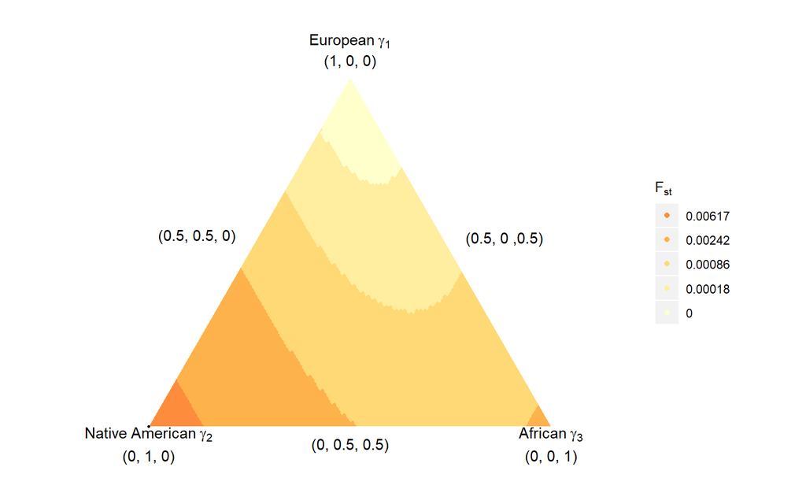

```r
plot_HorF("GATA101G01_12", y="Fst", breaks = c(-1, 0.00018, 0.00086, 0.00242, 0.00617, 0.01318, 0.02512, 0.04713, 0.13772, 1),
          label = c(0, 0.00018, 0.00086, 0.00242, 0.00617, 0.01318, 0.02512, 0.04713, 0.13772))
```